Home > Supervised Learning > Linear regression

# 2.1.1 Linear regression

We have already seen linear regression in the What is Data Science? Introduction but we will consider a more general setting here. We define - the input space $\mathcal{X} := \mathbb{R}^n$ and the output space $\mathcal{Y} := \mathbb{R}^m$ - and the hypothesis class
$$\mathcal{H} := \{\hat{f} : \mathbb{R}^n \to
\mathbb{R}^m | \exists W \in \mathbb{R}^{m\times n}, \hat{f}(x) =
Wx\}$$
To determine $\hat{f}$ from $N \in \mathbb{N}$ data points $(x_i, y_i)$ for $i = 1,..., N$ we consider the problem
$$\min_{W \in \mathbb{R}^{m \times n}}
\frac{1}{2} \sum_{i=1}^N ||Wx_i - y_i||^2$$
Let us define the data matrix $X \in \mathbb{R}^{N \times n}$ with $X_{ij}:=(x_i)_j$, the matrix $Y \in \mathbb{R}^{N \times m}$ with $Y_{ij} := (y_i)_j$, and $\beta := W^T$, then we can rewrite this problem as

#### 2.1.1

$$\min_{\beta \in \mathbb{R}^{n \times m}}
\frac{1}{2} ||X \beta - Y||^2_{\text{Fro}}$$
where the Frobenius norm of a matrix $A \in \mathbb{R}^{N \times m}$ is defined as
$$||A||_{\text{Fro}}^2 := \sum_{i=1}^N \sum_{j=1}^m
|A_{ij}|^2 = \text{Tr}(AA^T)$$
(The sum of squares of all elements in the matrix) We will first examine the solvability of the optimization problem

#### Proposition 2.1.1

If the matrix $X^TX \in \mathbb{R}^{n \times n}$ is invertible, then the unique solution of 2.1.1 is given by #### 2.1.2
$$\hat{\beta} := (X^T
X)^{-1}X^TY$$
Otherwise, there are infinitely many solutions.

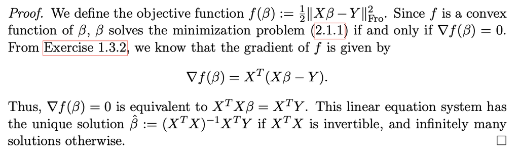

#### Remark 2.1.1 (Invertibility of $X^TX$)

Next we will try to understand the case where $X^TX$ is not invertible and to construct a “meaningful” solution for 2.1.1. To do this we recall

#### Definition 2.1.1 (Singular Value Decomposition)

A singular value decomposition of a matrix $X \in \mathbb{R}^{N \times n}$ is a decomposition of the form $X = U \Sigma V^T$ with orthogonal matrices $U \in \mathbb{R}^{N \times N}$ and $V \in \mathbb{R}^{n \times n}$ and a matrix $\Sigma \in \mathbb{R}^{N \times n}$ of the form
$$\Sigma = \begin{pmatrix}
\sigma_1 &\dots &\dots &\dots &\dots &\dots \\
\dots &\ddots &\dots &\dots &\dots &\vdots \\
\dots &\dots & \sigma_k & \dots &\dots &0\\
\dots &\dots &\dots &0&\dots &\vdots \\
\dots &\dots &\dots & &\ddots &\vdots \\
\dots &\dots &0&\dots &\dots &0
\end{pmatrix}$$
with $k \leq n$ singular values $\sigma_1 \geq \sigma_2 \geq \dots \geq \sigma_k \gt 0$ (Singular values are ordered by largest to smallest along the diagonal). We define the pseudo inverse of $X$ as
$$X^\dagger = V \Sigma^\dagger U^T$$
where $\Sigma^\dagger \in \mathbb{R}^{n \times N}$ is given by
$$\Sigma^\dagger =
\begin{pmatrix}
\frac{1}{\sigma_1} &\dots &\dots &\dots &\dots
&\dots \\
\dots &\ddots &\dots &\dots &\dots &\vdots \\
\dots &\dots & \frac{1}{\sigma_k} & \dots &\dots
&0\\
\dots &\dots &\dots &0&\dots &\vdots \\
\dots &\dots &\dots & &\ddots &\vdots \\
\dots &\dots &0&\dots &\dots &0
\end{pmatrix}$$

#### Remark 2.1.2 The existence of the SVD can be proven by applying the Spectral Theorem to the matrix $X^TX$

#### Proposition 2.1.2. The following holds:

$$X X^\dagger X = X, \hspace{0.5cm}
X^\dagger X X^\dagger = X^\dagger$$
$$X^\dagger X \text{ and } XX^\dagger \text{ are
symmetric}$$
We observe that for the SVD $X = U \Sigma V^T$, it holds that
$$X^TX = (U \Sigma V^T)^T U \Sigma V^T = V \Sigma^T
U^T U \Sigma V^T = V\Sigma^T \Sigma V^T$$

#### Definition of an Orthogonal matrix

An orthogonal matrix $U$ is a **square matrix** whose columns (and rows) form an orthonormal set. This means:

- Orthonormal columns: Each column vector has a unit length ($||u_i|| = 1$) and any two distinct columns are perpendicular ($u_i \cdot u_j = 0$ for $i \neq j$)
- Inverse property: The inverse of $U$ is equal to its transpose: $U^T = U^{-1}$
  - if $i = j: u_i \cdot u_j = 1$ (unit vectors)
- Orthogonal matrices represent rotations or reflections in space

#### Back to the previous definition

Thus, we have found a diagonalization (and in particular, a singular value decomposition) of $X^TX$. The positive eigenvalues of $X^TX$ are exactly given by $\sigma_i^2$ for $i = 1,..., k$. In the case that $k = n,$ i.e. there are $n$ singular values, $X^TX$ is invertible with $(X^TX)^{-1} = VDV^T$ where $D =\text{diag}(\sigma_1^{-2}, ..., \sigma_n^{-2})$. Otherwise, we can use the pseudoinverse of $X^TX$ to calculate the solution of 2.1.1 with minimal norm.

#### Proposition 2.1.3

If the matrix $X^TX \in \mathbb{R}^{n \times n}$ is not invertible, then the solution of 2.1.1 with minimal norm is given by

#### 2.1.3

$$\hat{\beta} := (X^TX)^\dagger X^T
Y$$
(similarly see 2.1.2) where $(X^TX)^\dagger = VDV^T$ with (D := squares of the singular values of $X$)
$$D := \begin{pmatrix}
\frac{1}{\sigma_1^2} &\dots &\dots &\dots \\
\dots &\ddots &\dots &\dots \\
\dots &\dots & \frac{1}{\sigma_k^2} & \dots \\
\dots &\dots & \dots & 0_{n-k,
n-k}\end{pmatrix}$$

#### How do we know if $X^T X$ is invertible?

$$X = \begin{pmatrix}
\dots & x_1^T & \dots \\
& \vdots & \\
\dots & x_N^T & \dots
\end{pmatrix}$$
$C = X^TX$ is the covariance matrix. If you have data for which the variance of one direction is zero, you know that the eigenvalue for this direction will be 0 and $C$ will not be invertible. –> A (covariance?) Matrix with an eigenvalue of 0 is not invertible

Next up: 2.1.2 Regularized Linear Models